# Manuscript DSP Code

16 April 2026

# Overview of experiment and analyses

This is the complete analysis of the DSP task using white matter and behavior and hormones.

Reading in and prepping our data

```r
##### Mac Desktop path
working_dir <- "/Users/danielacossio/Desktop/Scripts/Projects/SNAG/DSI_studio/DSP"

# Moving to save all figrues and output into a different folder bc it's too big for github

outputdir <- "/Users/danielacossio/Documents/Chrastil_Lab/Projects/SNAG/DSI/DSP"

###### Laptop path

# working_dir <- "/Users/danielacossio/Desktop/Projects/SNAG/DSI_studio/DSP"
#
# outputdir <- "/Users/danielacossio/Library/CloudStorage/GoogleDrive-dcossio1@uci.edu/Other computers/My iMac/Chrastil_Lab/Projects/SNAG/DSI/DSP"

# path to the subject sheets
midlife_DSP_df <- read.csv(paste0(working_dir,"/Mid_DSP_DSI.csv"))

yng_DSP_df <-  read.csv(paste0(working_dir,"/DSP_yng_participant_info.csv"))

yng_DSP_scan_df <-  read.csv(paste0(working_dir,"/DSP_yng_participant_info.csv")) %>%  filter(Subject_ID != 84) %>% filter(Subject_ID != 80)
```

```r
# combining peri and post into one group
midlife_DSP_df$repo_status[midlife_DSP_df$repo_status =="Peri"]<-c("Peri_Post")
midlife_DSP_df$repo_status[midlife_DSP_df$repo_status =="Post"]<-c("Peri_Post")


#Creating group DF
Mid_dsp_fem_df <- midlife_DSP_df %>% filter(sex == "Female")
Mid_dsp_male_df <- midlife_DSP_df %>% filter(sex == "Male")
Mid_dsp_pre_df <- midlife_DSP_df %>% filter(repo_status == "Pre")
Mid_dsp_peripost_df <- midlife_DSP_df %>% filter(repo_status != "Pre") %>% filter(repo_status != "Men")
```

# Methods

## **Participants**

### Midlife

```r
midlife_DSP_df %>% dplyr::summarise(count = n(), mean = round(mean(age_spatial_years, na.rm = TRUE), digits = 2), sd = round(sd(age_spatial_years, na.rm = TRUE), digits = 2), min(age_spatial_years, na.rm = TRUE), max(age_spatial_years, na.rm = TRUE)) %>% `colnames<-`(c("N", "Mean age", "Age SD","Min age", "Max age")) %>%  kableExtra::kable() %>% kable_styling(bootstrap_options =  c("striped", "hover", "condensed"))
```

| N | Mean age | Age SD | Min age | Max age |
| --- | --- | --- | --- | --- |
| 68 | 50.37 | 3.75 | 44 | 61 |

```r
midlife_DSP_df %>% group_by(sex) %>%  dplyr::summarise(count = n(), mean = round(mean(age_spatial_years, na.rm = TRUE), digits = 2), sd = round(sd(age_spatial_years, na.rm = TRUE), digits = 2), min(age_spatial_years, na.rm = TRUE), max(age_spatial_years, na.rm = TRUE)) %>% `colnames<-`(c("sex","N", "Mean age", "Age SD","Min age", "Max age")) %>%  kableExtra::kable() %>% kable_styling(bootstrap_options =  c("striped", "hover", "condensed"))
```

| sex | N | Mean age | Age SD | Min age | Max age |
| --- | --- | --- | --- | --- | --- |
| Female | 45 | 50.33 | 3.57 | 44 | 61 |
| Male | 23 | 50.43 | 4.15 | 44 | 61 |

### Young

- total subject with DSP = 27
- Total scans used in analysis= 25
- Total subjects excluded: 2
  - Excluded subs 80 and 84 due to low quality outliar
  - All subjects = 27
  - Men = 16
  - Women = 9

```r
yng_DSP_df %>% dplyr::summarise(count = n(), mean = round(mean(age_spatial_years, na.rm = TRUE),digits = 2), sd = round(sd(age_spatial_years, na.rm = TRUE),digits = 2), min(age_spatial_years, na.rm = TRUE), max(age_spatial_years, na.rm = TRUE))  %>% `colnames<-`(c("N", "Mean age", "Age SD","Min age", "Max age")) %>% kableExtra::kable() %>% kable_styling(bootstrap_options =  c("striped", "hover", "condensed"))
```

| N | Mean age | Age SD | Min age | Max age |
| --- | --- | --- | --- | --- |
| 27 | 20.26 | 2.65 | 18 | 28 |

```r
yng_DSP_scan_df %>% dplyr::summarise(count = n(), mean = round(mean(age_spatial_years, na.rm = TRUE),digits = 2), sd = round(sd(age_spatial_years, na.rm = TRUE),digits = 2), min(age_spatial_years, na.rm = TRUE), max(age_spatial_years, na.rm = TRUE)) %>% `colnames<-`(c( "N", "Mean age", "Age SD","Min age", "Max age")) %>% kableExtra::kable() %>% kable_styling(bootstrap_options =  c("striped", "hover", "condensed"))
```

| N | Mean age | Age SD | Min age | Max age |
| --- | --- | --- | --- | --- |
| 25 | 20.44 | 2.68 | 18 | 28 |

```r
yng_DSP_scan_df %>% group_by(sex) %>% dplyr::summarise(count = n(), mean = round(mean(age_spatial_years, na.rm = TRUE),digits = 2), sd = round(sd(age_spatial_years, na.rm = TRUE),digits = 2), min(age_spatial_years, na.rm = TRUE), max(age_spatial_years, na.rm = TRUE)) %>% `colnames<-`(c("sex", "N", "Mean age", "Age SD","Min age", "Max age")) %>% kableExtra::kable() %>% kable_styling(bootstrap_options =  c("striped", "hover", "condensed"))
```

| sex | N | Mean age | Age SD | Min age | Max age |
| --- | --- | --- | --- | --- | --- |
| Female | 9 | 20.56 | 2.83 | 18 | 26 |
| Male | 16 | 20.38 | 2.68 | 18 | 28 |

## **Scan parameters**

- Locations from UCSB and UCI

## **QSIprep**

- Version used: 0.16.0RC3
- The following parameters were used
  - dwi_denoise_window **5**
  - hmc_model **3dSHORE**
  - hmc-transform **Rigid**
  - shoreline_iters **2**

## **DSI Studio**

- Version and tags used via singularity container: **chen-2024-05-03**
- **Parameters**
  - T-threshold = 2.5
  - Length = 25
  - Permutation = 4,000
  - pruning 4
  - QA
  - Covariates: sex, age, and FNAME

## **Hormones and behavior**

I am doing a mediation analysis to understand the relation ship between white matter, hormones, and performance on the dual solution paradigm.

From shuying’s data, DSP is associated with estradial. Increased solution index is associated with increased solution index.

MD is negatively associated with Solution Index such that increased MD in the fornix is associated with less shortcuts. Essentially lower white matter integrity in fornix is associated with lower performance.

Hypothesis for mediation is that greater estradiol is driving the relationship in which greater integrity in the fornix for greater solution index.

X= Mean diffusivity in fornix  
Y= greater SI on DSP task  
M= Estradiol

Shuyings numbers are as follows from her behavioral task, idk who she excluded:  
Women: 47  
MEn:28  
Total:75

Daniela’s

Women: 45  
Men: 23  
Total: 68

Subjects I excluded 347 for Low quality outliar 424 for low quality outliar 372 for neurochistosomaisis 388 for cyst in cerebellum 352 for depression

These were excluded later from hippocampal analyses so i just excluded their behavior here as well. Adding these in gives me 77 which is still not the correct number of subjects. I’m not sure which one is the extra. For now I’ll add them back in but it shouldn’t affect much.

# Results

## Young Adult Summary Stats

**Total number of young adults with DSP**

- N = 27
- Mean SI = 0.27
- SD SI = 0.15

```r
yng_DSP_df %>% dplyr::summarise(count = n(), mean = mean(dsp_si_true_pct, na.rm = TRUE), sd = sd(dsp_si_true_pct, na.rm = TRUE), min(dsp_si_true_pct, na.rm = TRUE), max(dsp_si_true_pct, na.rm = TRUE)) %>% `colnames<-`(c("N", "Mean SI", "SI SD","Min SI", "Max SI"))%>% kableExtra::kable() %>% kable_styling(bootstrap_options =  c("striped", "hover", "condensed"))
```

| N | Mean SI | SI SD | Min SI | Max SI |
| --- | --- | --- | --- | --- |
| 27 | 0.2681167 | 0.1542762 | 0.0526316 | 0.7 |

**Total number of young adults with DSP+good scan**

- N = 25
- Mean = 0.26
- SD = 0.16

```r
yng_DSP_scan_df %>% dplyr::summarise(count = n(), mean = mean(dsp_si_true_pct, na.rm = TRUE), sd = sd(dsp_si_true_pct, na.rm = TRUE), min(dsp_si_true_pct, na.rm = TRUE), max(dsp_si_true_pct, na.rm = TRUE)) %>% `colnames<-`(c("N", "Mean SI", "SI SD","Min SI", "Max SI")) %>% kableExtra::kable() %>% kable_styling(bootstrap_options =  c("striped", "hover", "condensed"))
```

| N | Mean SI | SI SD | Min SI | Max SI |
| --- | --- | --- | --- | --- |
| 25 | 0.2607239 | 0.1571965 | 0.0526316 | 0.7 |

```r
yng_DSP_scan_df %>% dplyr::summarise(count = n(), mean = mean(dsp_success_pct, na.rm = TRUE), sd = sd(dsp_success_pct, na.rm = TRUE), min(dsp_success_pct, na.rm = TRUE), max(dsp_success_pct, na.rm = TRUE)) %>% `colnames<-`(c("N", "Mean acc", "acc SD","Min acc", "Max acc")) %>% kableExtra::kable() %>% kable_styling(bootstrap_options =  c("striped", "hover", "condensed"))
```

| N | Mean acc | acc SD | Min acc | Max acc |
| --- | --- | --- | --- | --- |
| 25 | 0.932 | 0.1009125 | 0.7 | 1 |

## Midlife Adults Summary Stats

**Total number of midlife adults**

- n = 68
- Mean = 0.23
- SD = 0.17

```r
midlife_DSP_df %>% dplyr::summarise(count = n(), mean = mean(dsp_si_true_pct, na.rm = TRUE), sd = sd(dsp_si_true_pct, na.rm = TRUE), min(dsp_si_true_pct, na.rm = TRUE), max(dsp_si_true_pct, na.rm = TRUE)) %>% `colnames<-`(c( "N", "Mean SI", "SI SD","Min SI", "Max SI")) %>% kableExtra::kable() %>% kable_styling(bootstrap_options =  c("striped", "hover", "condensed"))
```

| N | Mean SI | SI SD | Min SI | Max SI |
| --- | --- | --- | --- | --- |
| 68 | 0.2353573 | 0.1705766 | 0 | 0.8 |

```r
midlife_DSP_df %>% dplyr::summarise(count = n(), mean = mean(dsp_success_pct, na.rm = TRUE), sd = sd(dsp_success_pct, na.rm = TRUE), min(dsp_success_pct, na.rm = TRUE), max(dsp_success_pct, na.rm = TRUE)) %>% `colnames<-`(c( "N", "Mean acc", "acc SD","Min acc", "Max acc")) %>% kableExtra::kable() %>% kable_styling(bootstrap_options =  c("striped", "hover", "condensed"))
```

| N | Mean acc | acc SD | Min acc | Max acc |
| --- | --- | --- | --- | --- |
| 68 | 0.7100947 | 0.16792 | 0.3333333 | 1 |

**Midlife stats grouped by sex**

- Men
  - n = 23
  - mean = 0.19
  - SD = 0.15
- women
  - n = 45
  - mean = 0.25
  - SD = 0.18

```r
group_by(midlife_DSP_df, sex) %>% dplyr::summarise(count = n(), mean = mean(dsp_si_true_pct, na.rm = TRUE), sd = sd(dsp_si_true_pct, na.rm = TRUE), min(dsp_si_true_pct, na.rm = TRUE), max(dsp_si_true_pct, na.rm = TRUE)) %>% `colnames<-`(c("sex", "N", "Mean SI", "SI SD","Min SI", "Max SI"))%>% kableExtra::kable() %>% kable_styling(bootstrap_options =  c("striped", "hover", "condensed"))
```

| sex | N | Mean SI | SI SD | Min SI | Max SI |
| --- | --- | --- | --- | --- | --- |
| Female | 45 | 0.2580251 | 0.1778572 | 0 | 0.80 |
| Male | 23 | 0.1910073 | 0.1491239 | 0 | 0.55 |

**Midlife stats grouped by REPO**

- Pre
  - n = 18
  - mean = 0.31
  - SD = 0.17
- Peri Post
  - n = 27
  - mean = 0.22
  - SD = 0.18

```r
group_by(midlife_DSP_df, repo_status) %>% dplyr::summarise(count = n(), mean = mean(dsp_si_true_pct, na.rm = TRUE), sd = sd(dsp_si_true_pct, na.rm = TRUE), min(dsp_si_true_pct, na.rm = TRUE), max(dsp_si_true_pct, na.rm = TRUE)) %>% `colnames<-`(c("REPO", "N", "Mean SI", "SI SD","Min SI", "Max SI")) %>% kableExtra::kable() %>% kable_styling(bootstrap_options =  c("striped", "hover", "condensed"))
```

| REPO | N | Mean SI | SI SD | Min SI | Max SI |
| --- | --- | --- | --- | --- | --- |
| Men | 23 | 0.1910073 | 0.1491239 | 0.0000000 | 0.55 |
| Peri_Post | 27 | 0.2245087 | 0.1806166 | 0.0000000 | 0.80 |
| Pre | 18 | 0.3082997 | 0.1658939 | 0.0666667 | 0.80 |

## Midlife vs Young

### Solution Index

**Check normality of group**

Midlife solution index is not normally distributed p < 0.001

```r
shapiro.test(midlife_DSP_df$dsp_si_true_pct)
```

```
##
##  Shapiro-Wilk normality test
##
## data:  midlife_DSP_df$dsp_si_true_pct
## W = 0.9189, p-value = 0.0002913
```

```r
shapiro.test(yng_DSP_scan_df$dsp_si_true_pct)
```

```
##
##  Shapiro-Wilk normality test
##
## data:  yng_DSP_scan_df$dsp_si_true_pct
## W = 0.92772, p-value = 0.07698
```

Since one is not normal, I will use wilconox test.Young adults do not take more shortcuts than midlife adults, although we see it with shuyings data W = 749.5 p-value = 0.3857

```r
wilcox.test(midlife_DSP_df$dsp_si_true_pct, yng_DSP_scan_df$dsp_si_true_pct, paired=FALSE)
```

```
##
##  Wilcoxon rank sum test with continuity correction
##
## data:  midlife_DSP_df$dsp_si_true_pct and yng_DSP_scan_df$dsp_si_true_pct
## W = 749.5, p-value = 0.3857
## alternative hypothesis: true location shift is not equal to 0
```

**Creating Graph**

```r
all_SI_df <- midlife_DSP_df %>% dplyr::select(c("subject_id","sex","age_group","age_scan_years","dsp_si_true_pct","dsp_success_pct"))

temp_yng_df <- yng_DSP_scan_df %>% dplyr::select(c("Subject_ID","sex","age_group","age_scan_years","dsp_si_true_pct","dsp_success_pct")) %>% `colnames<-`(c("subject_id","sex","age_group","age_scan_years","dsp_si_true_pct","dsp_success_pct"))

all_SI_df <- rbind(all_SI_df,temp_yng_df)
```

```r
all_SI_df %>% kableExtra::kable() %>% kable_styling(bootstrap_options =  c("striped", "hover", "condensed"))
```

| subject_id | sex | age_group | age_scan_years | dsp_si_true_pct | dsp_success_pct |
| --- | --- | --- | --- | --- | --- |
| 301 | Female | Midlife | 60 | 0.2727273 | 0.5500000 |
| 306 | Female | Midlife | 57 | 0.2500000 | 0.4000000 |
| 310 | Female | Midlife | 49 | 0.1538462 | 0.6500000 |
| 311 | Female | Midlife | 50 | 0.0000000 | 0.6500000 |
| 312 | Female | Midlife | 47 | 0.2500000 | 0.6000000 |
| 313 | Female | Midlife | 53 | 0.0000000 | 0.7500000 |
| 315 | Female | Midlife | 43 | 0.2307692 | 0.6500000 |
| 318 | Female | Midlife | 49 | 0.1428571 | 0.9333333 |
| 319 | Male | Midlife | 60 | 0.0833333 | 0.6000000 |
| 321 | Male | Midlife | 50 | 0.2000000 | 0.7500000 |
| 322 | Male | Midlife | 48 | 0.1538462 | 0.6500000 |
| 323 | Female | Midlife | 48 | 0.4000000 | 0.7500000 |
| 324 | Female | Midlife | 48 | 0.3333333 | 0.4500000 |
| 327 | Female | Midlife | 52 | 0.0000000 | 0.9500000 |
| 330 | Male | Midlife | 54 | 0.1176471 | 0.8500000 |
| 343 | Male | Midlife | 55 | 0.1818182 | 0.5500000 |
| 345 | Male | Midlife | 49 | 0.0833333 | 0.6000000 |
| 346 | Male | Midlife | 55 | 0.1764706 | 0.8500000 |
| 348 | Male | Midlife | 48 | 0.0000000 | 0.8500000 |
| 351 | Female | Midlife | 49 | 0.3333333 | 0.6000000 |
| 353 | Male | Midlife | 44 | 0.0000000 | 0.9500000 |
| 354 | Male | Midlife | 47 | 0.1111111 | 0.9000000 |
| 356 | Female | Midlife | 49 | 0.0833333 | 0.8000000 |
| 357 | Male | Midlife | 50 | 0.3529412 | 0.8500000 |
| 358 | Female | Midlife | 53 | 0.2500000 | 0.6000000 |
| 360 | Male | Midlife | 48 | 0.2000000 | 0.7500000 |
| 362 | Female | Midlife | 53 | 0.1875000 | 0.8000000 |
| 363 | Male | Midlife | 49 | 0.0666667 | 0.7500000 |
| 364 | Male | Midlife | 53 | 0.2500000 | 0.8000000 |
| 373 | Female | Midlife | 52 | 0.1333333 | 0.7500000 |

[output cut: 63 more lines]

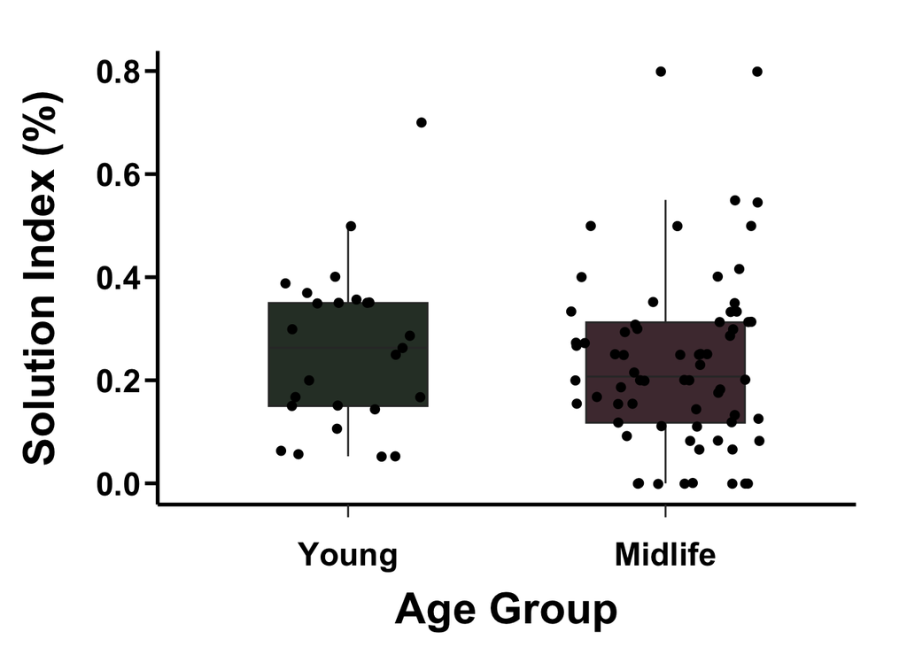

### Success

Young adults are significant better at wayfinding than midlife adults W = 223, p-value = 4.806e-08

```r
wilcox.test(midlife_DSP_df$dsp_success_pct, yng_DSP_scan_df$dsp_success_pct, paired=FALSE)
```

```
##
##  Wilcoxon rank sum test with continuity correction
##
## data:  midlife_DSP_df$dsp_success_pct and yng_DSP_scan_df$dsp_success_pct
## W = 223, p-value = 4.806e-08
## alternative hypothesis: true location shift is not equal to 0
```

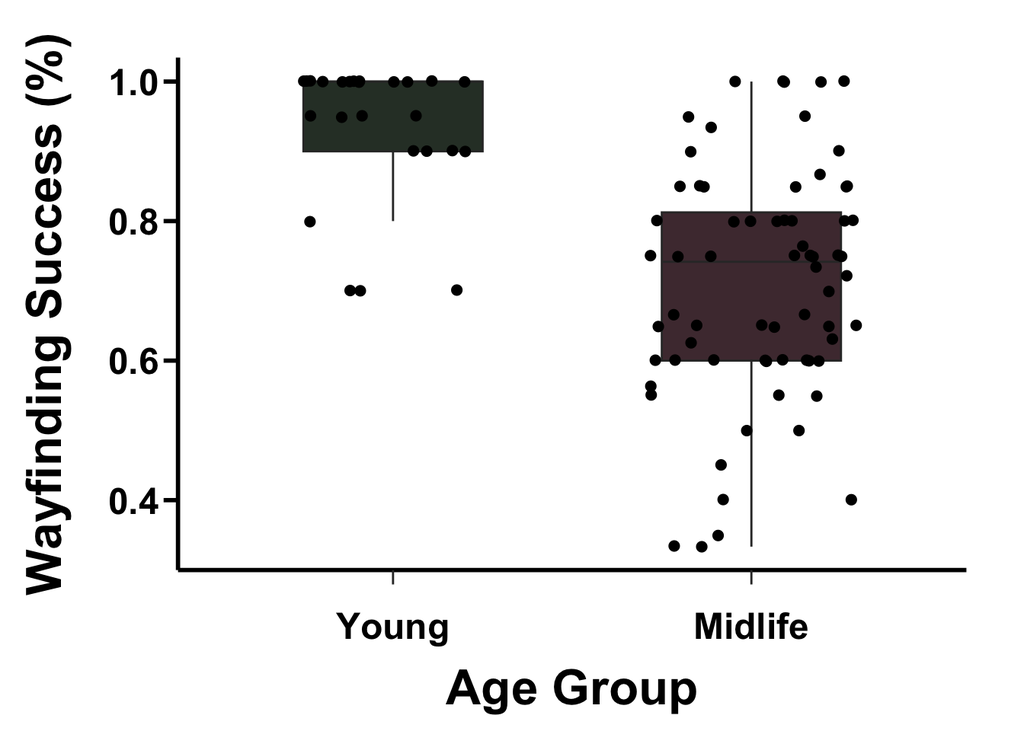

## Midlife men vs women

Not sig different here either’ W = 653.5, p-value = 0.07849

```r
wilcox.test(Mid_dsp_fem_df$dsp_si_true_pct, Mid_dsp_male_df$dsp_si_true_pct)
```

```
##
##  Wilcoxon rank sum test with continuity correction
##
## data:  Mid_dsp_fem_df$dsp_si_true_pct and Mid_dsp_male_df$dsp_si_true_pct
## W = 653.5, p-value = 0.07849
## alternative hypothesis: true location shift is not equal to 0
```

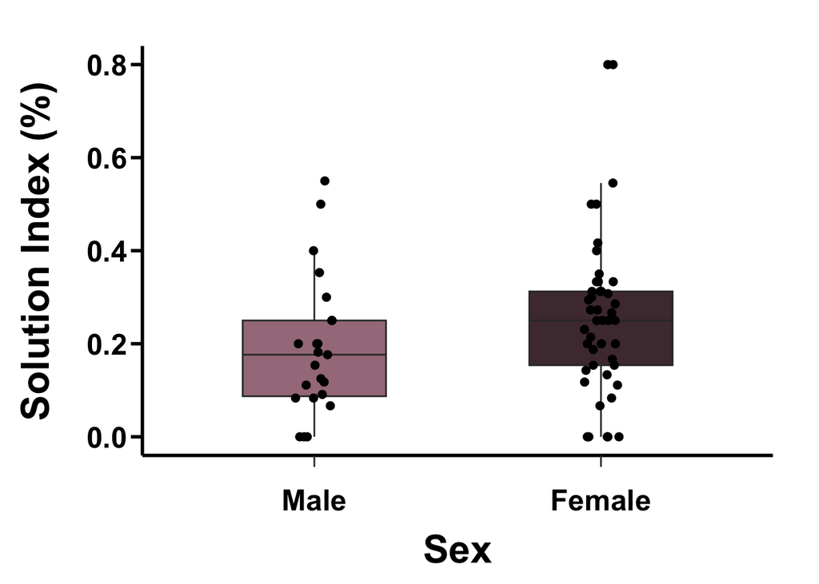

## Midlife X Young X sex and age interaction

### Solution Index

Here we are using the “all_SI_df” variable which as mid and young adults

**ANOVA**

No main effect of age or sex but an interaction Relationship between SI and age is dependent on sex 0.00724

```r
DSP_SI_ANOVA <- aov(dsp_si_true_pct ~ age_group * sex, data = all_SI_df)
#There is a marginal effect of REPO on performance

summary(DSP_SI_ANOVA)
```

```
##               Df Sum Sq Mean Sq F value  Pr(>F)
## age_group      1 0.0118 0.01176   0.447 0.50555
## sex            1 0.0011 0.00107   0.040 0.84103
## age_group:sex  1 0.1989 0.19887   7.556 0.00724 **
## Residuals     89 2.3426 0.02632
## ---
## Signif. codes:  0 '***' 0.001 '**' 0.01 '*' 0.05 '.' 0.1 ' ' 1
```

```r
Anova(DSP_SI_ANOVA, type="III")
```

```
## Anova Table (Type III tests)
##
## Response: dsp_si_true_pct
##                Sum Sq Df  F value    Pr(>F)
## (Intercept)   2.99596  1 113.8237 < 2.2e-16 ***
## age_group     0.06631  1   2.5194  0.116000
## sex           0.06836  1   2.5972  0.110592
## age_group:sex 0.19887  1   7.5557  0.007243 **
## Residuals     2.34258 89
## ---
## Signif. codes:  0 '***' 0.001 '**' 0.01 '*' 0.05 '.' 0.1 ' ' 1
```

```r
aov_DSP_SI <- Anova(DSP_SI_ANOVA, type="III")
anova_stats(aov_DSP_SI)
```

```
## Type 3 ANOVAs only give sensible and informative results when covariates
##   are mean-centered and factors are coded with orthogonal contrasts (such
##   as those produced by `contr.sum`, `contr.poly`, or `contr.helmert`, but
##   *not* by the default `contr.treatment`).
```

```
## etasq | partial.etasq | omegasq | partial.omegasq | epsilonsq | cohens.f
## ------------------------------------------------------------------------
## 0.025 |         0.028 |   0.015 |           0.016 |     0.015 |    0.168
## 0.026 |         0.028 |   0.016 |           0.017 |     0.016 |    0.171
## 0.074 |         0.078 |   0.064 |           0.066 |     0.064 |    0.291
##       |               |         |                 |           |
##
## etasq |          term | sumsq | df | meansq | statistic | p.value | power
## -------------------------------------------------------------------------
## 0.025 |     age_group | 0.066 |  1 |  0.066 |     2.519 |   0.116 | 0.355
## 0.026 |           sex | 0.068 |  1 |  0.068 |     2.597 |   0.111 | 0.364
## 0.074 | age_group:sex | 0.199 |  1 |  0.199 |     7.556 |   0.007 | 0.785
##       |     Residuals | 2.343 | 89 |  0.026 |           |         |
```

```r
all_SI_df %>%
  group_by(age_group) %>%
  anova_test(dsp_si_true_pct ~ sex,
             type = "III",
             effect.size = "pes") %>%
  get_anova_table() %>%
  adjust_pvalue(method = "bonferroni")
```

```
## # A tibble: 2 × 9
##   age_group Effect   DFn   DFd     F     p `p<.05`   pes p.adj
##   <chr>     <chr>  <dbl> <dbl> <dbl> <dbl> <chr>   <dbl> <dbl>
## 1 Midlife   sex        1    66  2.40 0.126 ""      0.035 0.252
## 2 Young     sex        1    23  6.56 0.017 "*"     0.222 0.034
```

```r
# Effect of treatment at each level of Sex
all_SI_df %>%
  group_by(sex) %>%
  anova_test(dsp_si_true_pct ~ age_group,
             type = "III",
             effect.size = "pes") %>%
  get_anova_table() %>%
  adjust_pvalue(method = "bonferroni")
```

```
## # A tibble: 2 × 9
##   sex    Effect      DFn   DFd     F     p `p<.05`   pes p.adj
##   <chr>  <chr>     <dbl> <dbl> <dbl> <dbl> <chr>   <dbl> <dbl>
## 1 Female age_group     1    52  2.31 0.135 ""      0.043 0.27
## 2 Male   age_group     1    37  6.34 0.016 "*"     0.146 0.032
```

```r
dev.size()
```

```
## [1] 7 5
```

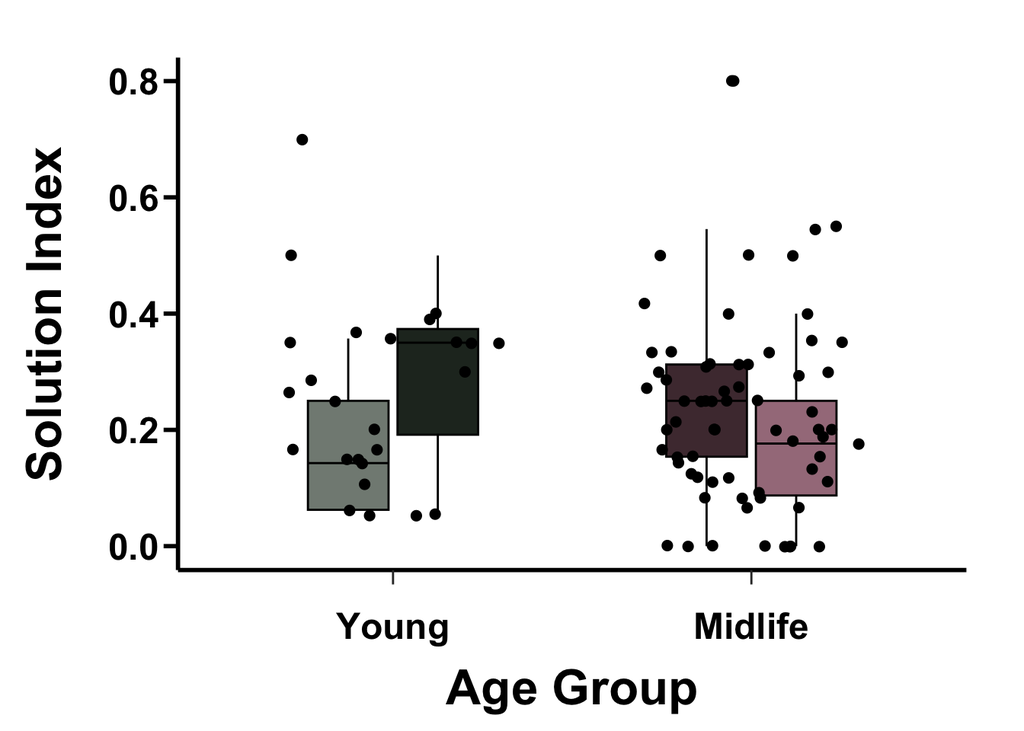

```r
all_SI_df %>% ggplot(aes(
  x = factor(age_group, levels = c("Young", "Midlife")),
  y = dsp_si_true_pct,
  fill = interaction(age_group,sex),
)) + geom_boxplot(width = 0.5,
                  fatten = 1,
                  outliers = FALSE,
                    color = "black") +
  geom_jitter(width = 0.3, size = 2) +
  #geom_point(size=2) +
  scale_fill_manual(values = c(Young.Male ="#253027", Young.Female ="#828a83", Midlife.Female = "#4e363e", Midlife.Male = "#a57c8a")) +
  scale_y_continuous(breaks = seq(0, 1, by = 0.2)) +
  xlab("Age Group") +
  ylab("Solution Index") +
  theme(
    axis.title.x = element_text(vjust = -3, size = 24, face = "bold"),
    axis.title.y = element_text(vjust = 4, size = 24,face = "bold"),
    axis.text.x = element_text(
      size = 18,
      color = "black",
      vjust = -2,
      face = "bold"
    ),
    axis.text.y = element_text(
      size = 18,
      color = "black",
      hjust = 2,
      face = "bold"
    ),
    axis.ticks.y = element_line(color = "black",
                                linewidth =1 ),
    #axis.ticks.x = element_blank(),
    axis.ticks.length = unit(0.25, "cm"),
    panel.background = element_blank(),
    axis.line = element_line(colour = "black", linewidth = 1),
    legend.position = "none",
    plot.margin = margin(1,1, 1, 1, "cm"),
  )
```

```r
ggsave(paste0(outputdir,"/DSP_SI_age_sex_boxplot.tiff"))
# see code below to add a significance label
 #ggsignif::geom_signif(annotations ="*", y_position = c(1), xmin = c(2), xmax =c(3)) +
```

### Success

no interaction

```r
DSP_success_ANOVA <- aov(dsp_success_pct ~ age_group * sex, data = all_SI_df)
#There is a marginal effect of REPO on performance

summary(DSP_success_ANOVA)
```

```
##               Df Sum Sq Mean Sq F value   Pr(>F)
## age_group      1 0.9001  0.9001  40.237 9.13e-09 ***
## sex            1 0.1409  0.1409   6.300   0.0139 *
## age_group:sex  1 0.0017  0.0017   0.076   0.7839
## Residuals     89 1.9910  0.0224
## ---
## Signif. codes:  0 '***' 0.001 '**' 0.01 '*' 0.05 '.' 0.1 ' ' 1
```

```r
dev.size()
```

```
## [1] 7 5
```

[figure not shown]

```r
all_SI_df %>% ggplot(aes(
  x = factor(age_group, levels = c("Young", "Midlife")),
  y = dsp_success_pct,
  fill = interaction(age_group,sex),
)) + geom_boxplot(width = 0.5,
                  fatten = 1,
                  outliers = FALSE,
                    color = "black") +
  geom_jitter(width = 0.3, size = 2) +
  ggsignif::geom_signif(annotations ="*", y_position = c(1.1), xmin = c(0.7), xmax =c(2.25)) +
  #geom_point(size=2) +
    scale_fill_manual(values = c(Young.Male ="#253027", Young.Female ="#828a83", Midlife.Female = "#4e363e", Midlife.Male = "#a57c8a"))+
  scale_y_continuous(breaks = seq(0, 1, by = 0.2)) +
  xlab("Age Group") +
  ylab("Solution Index") +
  theme(
    axis.title.x = element_text(vjust = -3, size = 24, face = "bold"),
    axis.title.y = element_text(vjust = 4, size = 24,face = "bold"),
    axis.text.x = element_text(
      size = 18,
      color = "black",
      vjust = -2,
      face = "bold"
    ),
    axis.text.y = element_text(
      size = 18,
      color = "black",
      hjust = 2,
      face = "bold"
    ),
    axis.ticks.y = element_line(color = "black",
                                linewidth =1 ),
    #axis.ticks.x = element_blank(),
    axis.ticks.length = unit(0.25, "cm"),
    panel.background = element_blank(),
    axis.line = element_line(colour = "black", linewidth = 1),
    legend.position = "none",
    plot.margin = margin(1,1, 1, 1, "cm"),
  )
```

```r
ggsave(paste0(outputdir,"/DSP_success_age_s_boxplot.tiff"))
# see code below to add a significance label
 #+
```

## Midlife pre vs peri_post

### SI

These are slighlty significantly different 0.037

```r
wilcox.test(Mid_dsp_pre_df$dsp_si_true_pct, Mid_dsp_peripost_df$dsp_si_true_pct)
```

```
##
##  Wilcoxon rank sum test with continuity correction
##
## data:  Mid_dsp_pre_df$dsp_si_true_pct and Mid_dsp_peripost_df$dsp_si_true_pct
## W = 333, p-value = 0.03783
## alternative hypothesis: true location shift is not equal to 0
```

```r
all_menopause_df <- rbind(Mid_dsp_pre_df,Mid_dsp_peripost_df)
```

```r
dev.size()
```

```
## [1] 7 5
```

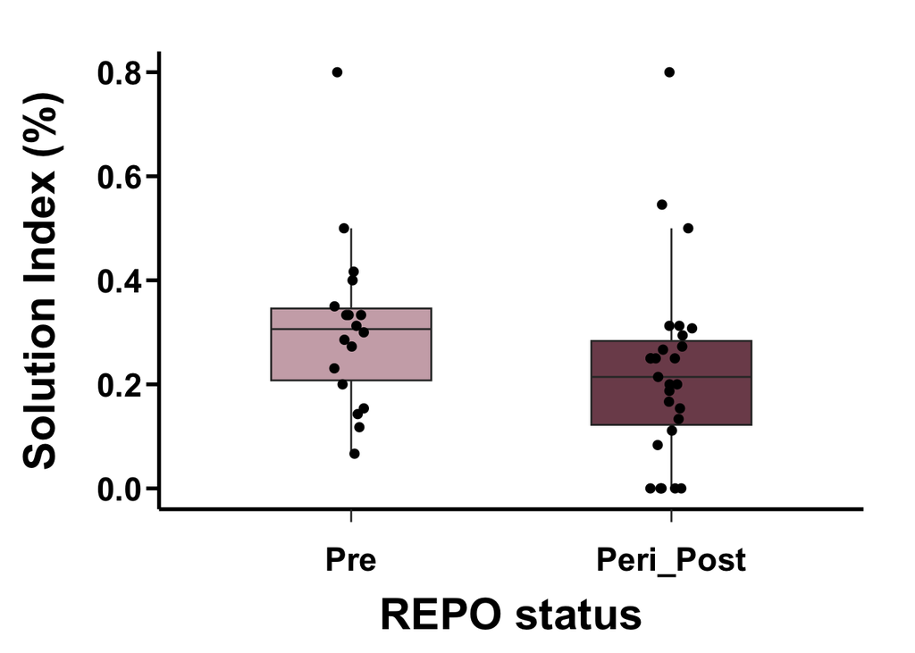

```r
all_menopause_df %>% ggplot(aes(
  x = factor(repo_status, levels = c("Pre", "Peri_Post")),
  y = dsp_si_true_pct,
  fill = repo_status
)) + geom_boxplot(width = 0.5,
                  fatten = 1,
                  outliers = FALSE) +
  #geom_jitter(width = 0.3, size = 2) +
  geom_point(position=position_jitterdodge(0.2, dodge.width = .1),size=2) +
  scale_fill_manual(values = c("#7d4c5a", "#cdadb6")) +
  scale_y_continuous(breaks = seq(0, 1, by = 0.2)) +
  xlab("REPO status") +
  ylab("Solution Index (%)") +
  theme(
    axis.title.x = element_text(vjust = -3, size = 24, face = "bold"),
    axis.title.y = element_text(vjust = 4, size = 24,face = "bold"),
    axis.text.x = element_text(
      size = 18,
      color = "black",
      vjust = -2,
      face = "bold"
    ),
    axis.text.y = element_text(
      size = 18,
      color = "black",
      hjust = 2,
      face = "bold"
    ),
    axis.ticks.y = element_line(color = "black",
                                linewidth =1 ),
    #axis.ticks.x = element_blank(),
    axis.ticks.length = unit(0.25, "cm"),
    panel.background = element_blank(),
    axis.line = element_line(colour = "black", linewidth = 1),
    legend.position = "none",
    plot.margin = margin(1,1, 1, 1, "cm"),
  )
```

```r
ggsave(paste0(outputdir,"/DSP_meno_diff_SI.tiff"))
```

### Success

not significantly different 0.3645

```r
wilcox.test(Mid_dsp_pre_df$dsp_success_pct, Mid_dsp_peripost_df$dsp_success_pct)
```

```
##
##  Wilcoxon rank sum test with continuity correction
##
## data:  Mid_dsp_pre_df$dsp_success_pct and Mid_dsp_peripost_df$dsp_success_pct
## W = 282.5, p-value = 0.3645
## alternative hypothesis: true location shift is not equal to 0
```

```r
dev.size()
```

```
## [1] 7 5
```

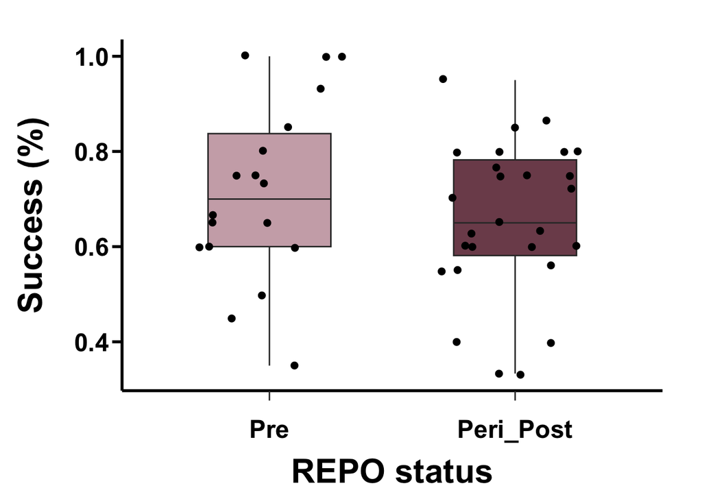

```r
all_menopause_df %>% ggplot(aes(
  x = factor(repo_status, levels = c("Pre", "Peri_Post")),
  y = dsp_success_pct,
  fill = repo_status
)) + geom_boxplot(width = 0.5,
                  fatten = 1,
                  outliers = FALSE) +
  geom_jitter(width = 0.3, size = 2) +
  #geom_point(size=2) +
  scale_fill_manual(values = c("#7d4c5a", "#cdadb6")) +
  scale_y_continuous(breaks = seq(0, 1, by = 0.2)) +
  xlab("REPO status") +
  ylab("Success (%)") +
  theme(
    axis.title.x = element_text(vjust = -3, size = 24, face = "bold"),
    axis.title.y = element_text(vjust = 4, size = 24,face = "bold"),
    axis.text.x = element_text(
      size = 18,
      color = "black",
      vjust = -2,
      face = "bold"
    ),
    axis.text.y = element_text(
      size = 18,
      color = "black",
      hjust = 2,
      face = "bold"
    ),
    axis.ticks.y = element_line(color = "black",
                                linewidth =1 ),
    #axis.ticks.x = element_blank(),
    axis.ticks.length = unit(0.25, "cm"),
    panel.background = element_blank(),
    axis.line = element_line(colour = "black", linewidth = 1),
    legend.position = "none",
    plot.margin = margin(1,1, 1, 1, "cm"),
  )
```

```r
ggsave(paste0(outputdir,"/DSP_meno_diff_success.tiff"))
```

## Hormones

```r
hormone_comparison <-  data.frame(matrix(ncol = 5, nrow = 0)) %>% `colnames<-`(c("hormone","statistic","p.value","method","alternative"))
```

### Estradiol

#### Comparing pre and peri post hormone levels between pre and peri_post

```r
est_wilx_test <- wilcox.test(Mid_dsp_pre_df$estradiol_spatial_pg_ml, Mid_dsp_peripost_df$estradiol_spatial_pg_ml) %>% broom::tidy() %>%  mutate(hormone = "Estradiol") %>% dplyr::select("hormone",everything())

hormone_comparison <- rbind(hormone_comparison, est_wilx_test)
```

Pre menopausal estradiol stats

```r
Mid_dsp_pre_df %>% dplyr::summarise(count = n(), mean = mean(estradiol_spatial_pg_ml, na.rm = TRUE), sd = sd(estradiol_spatial_pg_ml, na.rm = TRUE))  %>% kableExtra::kable() %>% kable_styling(bootstrap_options =  c("striped", "hover", "condensed"))
```

| count | mean | sd |
| --- | --- | --- |
| 18 | 113.2072 | 90.81308 |

Pre and peripost menopausal estradiol stats

```r
Mid_dsp_peripost_df %>% dplyr::summarise(count = n(), mean = mean(estradiol_spatial_pg_ml, na.rm = TRUE), sd = sd(estradiol_spatial_pg_ml, na.rm = TRUE)) %>% kableExtra::kable() %>% kable_styling(bootstrap_options =  c("striped", "hover", "condensed"))
```

| count | mean | sd |
| --- | --- | --- |
| 27 | 27.96667 | 45.15553 |

```r
# Extract 9 x 6 portrait

dev.size()
```

```
## [1] 7 5
```

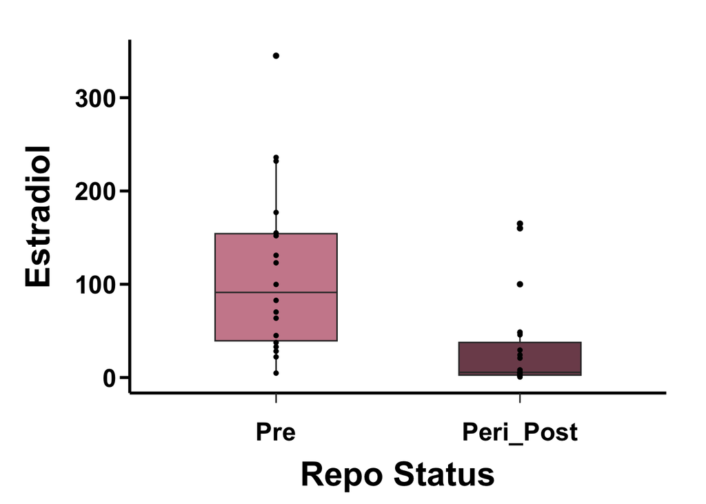

```r
all_menopause_df %>% ggplot(aes(x = factor(repo_status, levels=c("Pre", "Peri_Post")), y = estradiol_spatial_pg_ml, fill= repo_status)) +
  geom_boxplot(width=0.5,fatten = 1, show.legend = FALSE) +
  geom_point(shape=16) +
  scale_fill_manual(values=c("#7d4c5a", "#CD8A9B"))+
  #scale_y_continuous(breaks = seq(0, 1, by = 0.2)) +
   xlab("Repo Status")+
   ylab("Estradiol") +
  theme(
    axis.title.x = element_text(vjust = -3, size = 24, face = "bold"),
    axis.title.y = element_text(vjust = 3, size = 24,face = "bold"),
    axis.text.x = element_text(
      size = 18,
      color = "black",
      vjust = -2,
      face = "bold"
    ),
    axis.text.y = element_text(
      size = 18,
      color = "black",
      hjust = 1,
      face = "bold"
    ),
    axis.ticks.y = element_line(color = "black",
                                linewidth =1 ),
    #axis.ticks.x = element_blank(),
    axis.ticks.length = unit(0.25, "cm"),
    panel.background = element_blank(),
    axis.line = element_line(colour = "black", linewidth = 1),
    legend.position = "none",
    plot.margin = margin(1,1, 1, 1, "cm"),
  )
```

```r
ggsave(paste0(outputdir,"/DSP_Est_boxplot.tiff"))
```

#### Estradiol and SI

**Partial correlations** **One-tailed correlation controlling for AGE using all females**

Here we want to control for age. ] Originally shuying did one tailed but we decided to go with two tailed. **Estradiol is significantly associated with SI when controlling for age (n=45, r(43)=0.37, p=0.014).**

```r
pcor.test(Mid_dsp_fem_df$estradiol_spatial_pg_ml,
          Mid_dsp_fem_df$dsp_si_true_pct,
          Mid_dsp_fem_df$age_spatial_years,
          method = "spearman")
```

```
##   estimate    p.value statistic  n gp   Method
## 1 0.369274 0.01363063  2.575182 45  1 spearman
```

**Estradiol is significantly associated with SI (n=45, r(43)=0.46, p=0.0016).**

```r
cor.test(all_menopause_df$estradiol_spatial_pg_ml,
          all_menopause_df$dsp_si_true_pct,
          method = "spearman")
```

```
##
##  Spearman's rank correlation rho
##
## data:  all_menopause_df$estradiol_spatial_pg_ml and all_menopause_df$dsp_si_true_pct
## S = 8235.5, p-value = 0.00158
## alternative hypothesis: true rho is not equal to 0
## sample estimates:
##       rho
## 0.4574789
```

SCatter plot

```r
# Using
#PDF 9 X 6

dev.size()
```

```
## [1] 7 5
```

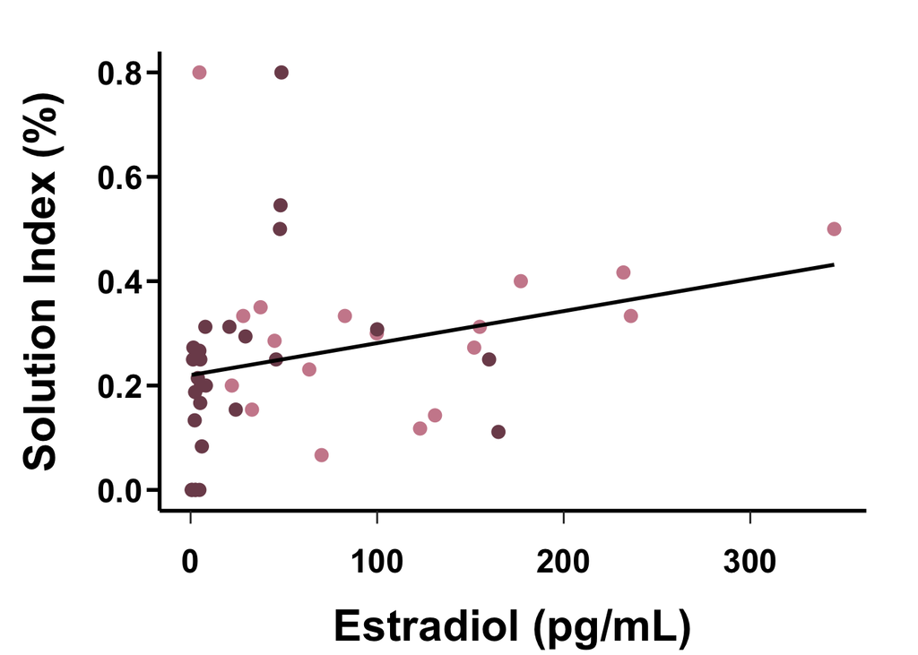

```r
all_menopause_df %>% ggplot(aes(x = estradiol_spatial_pg_ml,y = dsp_si_true_pct, color=repo_status)) +
  geom_point(aes(color = factor(repo_status)), size=3) +
  scale_color_manual(values=c( "#7d4c5a","#CD8A9B")) +
   stat_smooth(method = "lm",
              formula = y ~ x,
              geom = "smooth",
             color="Black",
             se=FALSE)+
  xlab("Estradiol (pg/mL)")+
  ylab("Solution Index (%)") +
  theme(
    axis.title.x = element_text(vjust = -4, size = 24, face = "bold"),
    axis.title.y = element_text(vjust = 4, size = 24,face = "bold"),
    axis.text.x = element_text(
      size = 18,
      color = "black",
      vjust = -2,
      face = "bold"
    ),
    axis.text.y = element_text(
      size = 18,
      color = "black",
      hjust = 1,
      face = "bold"
    ),
    axis.ticks.y = element_line(color = "black",
                                linewidth =1 ),
    #axis.ticks.x = element_blank(),
    axis.ticks.length = unit(0.25, "cm"),
    panel.background = element_blank(),
    axis.line = element_line(colour = "black", linewidth = 1),
    legend.position = "none",
    plot.margin = margin(1,1, 1, 1, "cm"),
  )
```

```r
ggsave(paste0(outputdir,"/DSP_Est_SI_scatterplot.tiff"))
```

Here, estradiol is still significantly associated with SI but it is reduced when controlling for age AND FNAME. p=0.016

```r
pcor.test(Mid_dsp_fem_df$estradiol_spatial_pg_ml,
          Mid_dsp_fem_df$dsp_si_true_pct,
          Mid_dsp_fem_df[,c("age_spatial_years","FNAME")],
          method = "spearman")
```

```
##    estimate    p.value statistic  n gp   Method
## 1 0.3644581 0.01627106  2.506036 45  2 spearman
```

##### Estradiol and Success

```r
pcor.test(Mid_dsp_fem_df$estradiol_spatial_pg_ml,
          Mid_dsp_fem_df$dsp_success_pct,
          Mid_dsp_fem_df$age_spatial_years,
          method = "spearman")
```

```
##     estimate   p.value  statistic  n gp   Method
## 1 -0.1519605 0.3247677 -0.9963882 45  1 spearman
```

```r
cor.test(all_menopause_df$estradiol_spatial_pg_ml,
          all_menopause_df$dsp_success_pct,
          method = "spearman")
```

```
##
##  Spearman's rank correlation rho
##
## data:  all_menopause_df$estradiol_spatial_pg_ml and all_menopause_df$dsp_success_pct
## S = 16328, p-value = 0.6215
## alternative hypothesis: true rho is not equal to 0
## sample estimates:
##         rho
## -0.07563185
```

SCatter plot

```r
# Using
#PDF 9 X 6

dev.size()
```

```
## [1] 7 5
```

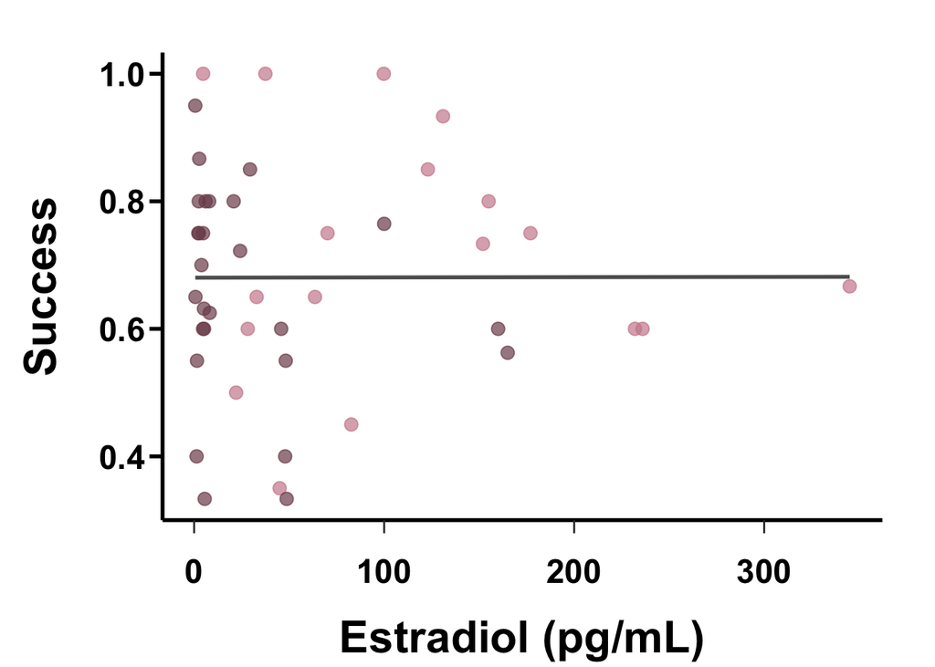

```r
all_menopause_df %>% ggplot(aes(x = estradiol_spatial_pg_ml,y = dsp_success_pct, color=repo_status)) +
  geom_point(aes(color = factor(repo_status)),size=3,alpha = 0.7) +
  scale_color_manual(values=c( "#7d4c5a","#CD8A9B")) +
   geom_line(stat = "smooth", method = "lm",
            formula = y ~ x,
             alpha = 0.7,
            color = "black",
            size = 1,
             se=FALSE) +
  xlab("Estradiol (pg/mL)")+
  ylab("Success") +
  theme(
    axis.title.x = element_text(vjust = -4, size = 24, face = "bold"),
    axis.title.y = element_text(vjust = 4, size = 24,face = "bold"),
    axis.text.x = element_text(
      size = 18,
      color = "black",
      vjust = -2,
      face = "bold"
    ),
    axis.text.y = element_text(
      size = 18,
      color = "black",
      hjust = 1,
      face = "bold"
    ),
    axis.ticks.y = element_line(color = "black",
                                linewidth =1 ),
    #axis.ticks.x = element_blank(),
    axis.ticks.length = unit(0.25, "cm"),
    panel.background = element_blank(),
    axis.line = element_line(colour = "black", linewidth = 1),
    legend.position = "none",
    plot.margin = margin(1,1, 1, 1, "cm"),
  )
```

```r
ggsave(paste0(outputdir,"/DSP_success_Est_scatterplot.tiff"))
```

### FSH + SI

**Partial correlations** **One-tailed correlation controlling for AGE using all females**

Here we want to control for age. ] Originally shuying did one tailed but we decided to go with two tailed. **FSH is not significantly associated with SI when controlling for age (n=45, r(43)=-0.16, p=0.29).**

```r
pcor.test(Mid_dsp_fem_df$fsh_spatial_miu_ml,
          Mid_dsp_fem_df$dsp_si_true_pct,
          Mid_dsp_fem_df$age_spatial_years,
          method = "spearman")
```

```
##     estimate  p.value statistic  n gp   Method
## 1 -0.1612583 0.295683 -1.058932 45  1 spearman
```

**FSH is significantly associated with SI (n=45, r(43)=-0.32, p=0.03).**

```r
cor.test(all_menopause_df$fsh_spatial_miu_ml,
          all_menopause_df$dsp_si_true_pct,
          method = "spearman")
```

```
##
##  Spearman's rank correlation rho
##
## data:  all_menopause_df$fsh_spatial_miu_ml and all_menopause_df$dsp_si_true_pct
## S = 20012, p-value = 0.03308
## alternative hypothesis: true rho is not equal to 0
## sample estimates:
##        rho
## -0.3183351
```

SCatter plot

```r
# Using
#PDF 9 X 6

dev.size()
```

```
## [1] 7 5
```

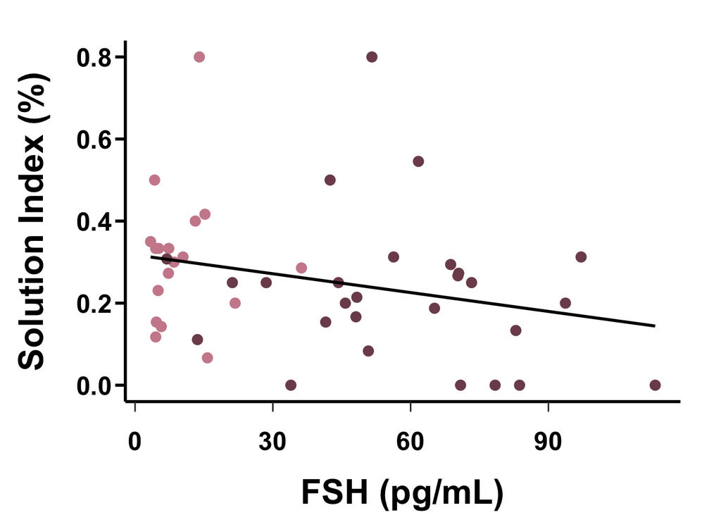

```r
all_menopause_df %>% ggplot(aes(x = fsh_spatial_miu_ml,y = dsp_si_true_pct, color=repo_status)) +
  geom_point(aes(color = factor(repo_status)), size=3) +
  scale_color_manual(values=c( "#7d4c5a","#CD8A9B")) +
   stat_smooth(method = "lm",
              formula = y ~ x,
              geom = "smooth",
             color="Black",
             se=FALSE)+
  xlab("FSH (pg/mL)")+
  ylab("Solution Index (%)") +
  theme(
    axis.title.x = element_text(vjust = -4, size = 24, face = "bold"),
    axis.title.y = element_text(vjust = 4, size = 24,face = "bold"),
    axis.text.x = element_text(
      size = 18,
      color = "black",
      vjust = -2,
      face = "bold"
    ),
    axis.text.y = element_text(
      size = 18,
      color = "black",
      hjust = 1,
      face = "bold"
    ),
    axis.ticks.y = element_line(color = "black",
                                linewidth =1 ),
    #axis.ticks.x = element_blank(),
    axis.ticks.length = unit(0.25, "cm"),
    panel.background = element_blank(),
    axis.line = element_line(colour = "black", linewidth = 1),
    legend.position = "none",
    plot.margin = margin(1,1, 1, 1, "cm"),
  )
```

```r
ggsave(paste0(outputdir,"/DSP_FSH_SI_scatterplot.tiff"))
```

### FSH + Success

**Partial correlations** **One-tailed correlation controlling for AGE using all females**

```r
pcor.test(Mid_dsp_fem_df$fsh_spatial_miu_ml,
          Mid_dsp_fem_df$dsp_success_pct,
          Mid_dsp_fem_df$age_spatial_years,
          method = "spearman")
```

```
##      estimate   p.value  statistic  n gp   Method
## 1 0.001832835 0.9905791 0.01187815 45  1 spearman
```

```r
cor.test(all_menopause_df$fsh_spatial_miu_ml,
          all_menopause_df$dsp_success_pct,
          method = "spearman")
```

```
##
##  Spearman's rank correlation rho
##
## data:  all_menopause_df$fsh_spatial_miu_ml and all_menopause_df$dsp_success_pct
## S = 16195, p-value = 0.6627
## alternative hypothesis: true rho is not equal to 0
## sample estimates:
##         rho
## -0.06683898
```

SCatter plot

```r
# Using
#PDF 9 X 6

dev.size()
```

```
## [1] 7 5
```

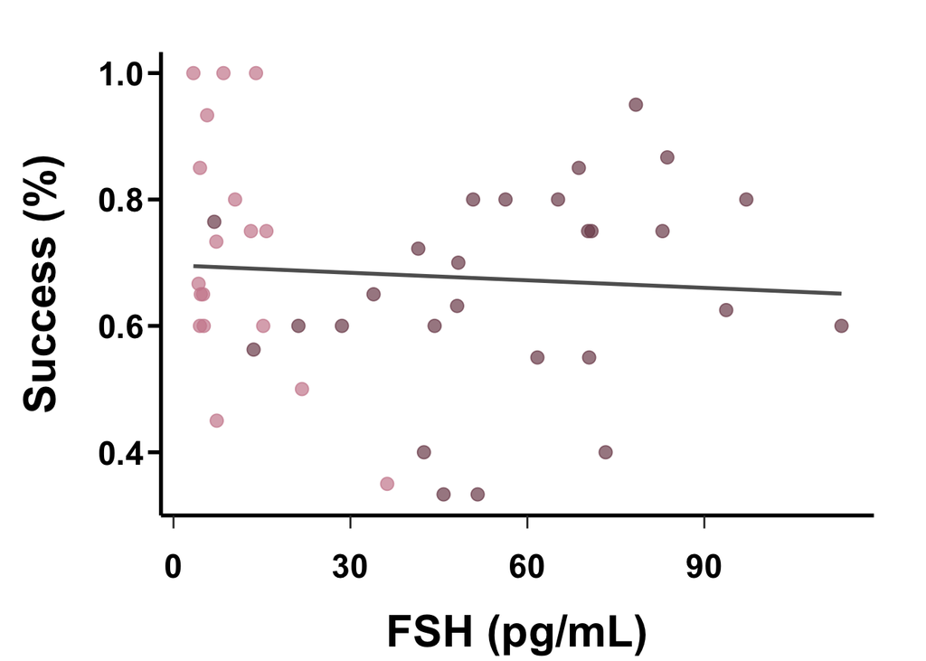

```r
all_menopause_df %>% ggplot(aes(x = fsh_spatial_miu_ml,y = dsp_success_pct, color=repo_status)) +
  geom_point(aes(color = factor(repo_status)),size=3,alpha = 0.7) +
  scale_color_manual(values=c( "#7d4c5a","#CD8A9B")) +
   geom_line(stat = "smooth", method = "lm",
            formula = y ~ x,
             alpha = 0.7,
            color = "black",
            size = 1,
             se=FALSE)+
  xlab("FSH (pg/mL)")+
  ylab("Success (%)") +
  theme(
    axis.title.x = element_text(vjust = -4, size = 24, face = "bold"),
    axis.title.y = element_text(vjust = 4, size = 24,face = "bold"),
    axis.text.x = element_text(
      size = 18,
      color = "black",
      vjust = -2,
      face = "bold"
    ),
    axis.text.y = element_text(
      size = 18,
      color = "black",
      hjust = 1,
      face = "bold"
    ),
    axis.ticks.y = element_line(color = "black",
                                linewidth =1 ),
    #axis.ticks.x = element_blank(),
    axis.ticks.length = unit(0.25, "cm"),
    panel.background = element_blank(),
    axis.line = element_line(colour = "black", linewidth = 1),
    legend.position = "none",
    plot.margin = margin(1,1, 1, 1, "cm"),
  )
```

```r
ggsave(paste0(outputdir,"/DSP_FSH_success_scatterplot.tiff"))
```

## DSP and FNAME

```r
pcor.test(Mid_dsp_fem_df$FNAME,
          Mid_dsp_fem_df$dsp_success_pct,
          Mid_dsp_fem_df$age_spatial_years,
          method = "spearman")
```

```
##    estimate  p.value statistic  n gp   Method
## 1 0.2356598 0.123568  1.571511 45  1 spearman
```

```r
corr.test(Mid_dsp_fem_df$FNAME,
          Mid_dsp_fem_df$dsp_success_pct, method = "spearman")
```

```
## Call:corr.test(x = Mid_dsp_fem_df$FNAME, y = Mid_dsp_fem_df$dsp_success_pct,
##     method = "spearman")
## Correlation matrix
## [1] 0.23
## Sample Size
## [1] 45
## These are the unadjusted probability values.
##   The probability values  adjusted for multiple tests are in the p.adj object.
## [1] 0.13
##
##  To see confidence intervals of the correlations, print with the short=FALSE option
```